# Exploring Happiness: A Data Story from people come from different countries

## Introduction

#### Happiness is a fundamental aspect of human experience, and understanding its triggers can provide valuable insights into our well-being. The HappyDB project offers a unique opportunity to analyze real-life instances of happiness, as reported by individuals from diverse backgrounds and contexts. By applying computational techniques, we can uncover hidden patterns within the different countries.

## Step 1

##### By generalising and summarising the datas from demographic.csv, we can see that 9,274 people from the US and 964 from India participated in the survey, while the participants from other countries was a few. In order to make the results of the study more typically, we looked at how Americans and Indians differed in terms of their happy moments.

```r
install.packages("tidyverse")
install.packages("tidyverse")
install.packages("tidytext")
library(tidyverse)
library(tidytext)
library(SnowballC)
library(dplyr)
library(readr)
data <- read_csv("/Users/fengxinsuoai/Downloads/clean.csv")
demographic <- read_csv("/Users/fengxinsuoai/Downloads/demographic.csv")
country_summary <- demographic %>%
  group_by(country) %>%
  summarise(Count = n()) %>%
  arrange(desc(Count))
print(country_summary)
```

| country | Count |
| --- | --- |
| USA | 9274 |
| IND | 964 |
| NA | 73 |
| CAN | 66 |
| VEN | 54 |
| GBR | 48 |
| PHL | 32 |
| MEX | 22 |
| AUS | 14 |
| BRA | 14 |

[output cut: 91 more lines]

## Step 2

##### If we summarise the keywords for people’s happy moments, we find that the top four moments for Americans are family, school, food and people.

```r
library(dplyr)
merged_data <- inner_join(demographic, data, by = "wid")
usa_data <- merged_data %>%
  filter(country == "USA")
terms <- c("family", "people", "pets", "shopping", "works", "entertainment", "food", "exercise", "school")

term_counts <- numeric(length(terms))

for (i in seq_along(terms)) {
  term_counts[i] <- sum(str_count(usa_data$cleaned_hm, terms[i]))
}

summary_table <- data.frame(Term = terms, Count = term_counts)
print(summary_table)
```

| Term | Count |
| --- | --- |
| family | 2721 |
| people | 819 |
| pets | 44 |
| shopping | 518 |
| works | 125 |
| entertainment | 13 |
| food | 1156 |
| exercise | 200 |
| school | 1672 |

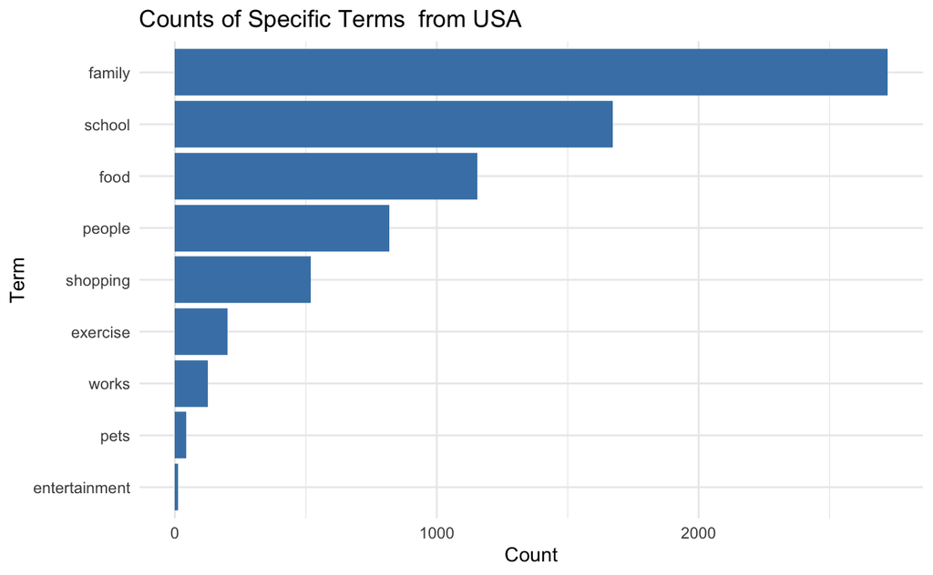

```r
library(ggplot2)
sorted_summary_table <- summary_table[order(-summary_table$Count), ]

ggplot(sorted_summary_table, aes(x = reorder(Term, Count), y = Count)) +
  geom_col(fill = "steelblue") +
  coord_flip() +
  labs(title = "Counts of Specific Terms  from USA",
       x = "Term",
       y = "Count") +
  theme_minimal()
```

##### However, for Indians, the top four moments are family, school, people and food, so we will focus on people and food.

```r
ind_data <- merged_data %>%
  filter(country == "IND")
terms <- c("family", "people", "pets", "shopping", "works", "entertainment", "food", "exercise", "school")

term_counts<- numeric(length(terms))

for (i in seq_along(terms)) {
  term_counts[i] <- sum(str_count(ind_data$cleaned_hm, terms[i]))
}

summary_table2 <- data.frame(Term = terms, Count = term_counts)
print(summary_table2)
```

| Term | Count |
| --- | --- |
| family | 1473 |
| people | 451 |
| pets | 3 |
| shopping | 208 |
| works | 35 |
| entertainment | 5 |
| food | 380 |
| exercise | 65 |
| school | 649 |

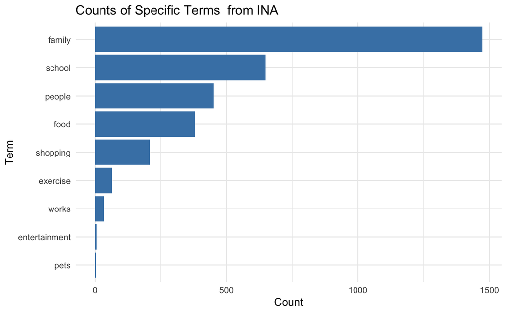

```r
library(ggplot2)

sorted_summary_table <- summary_table2[order(-summary_table2$Count), ]

ggplot(sorted_summary_table, aes(x = reorder(Term, Count), y = Count)) +
  geom_col(fill = "steelblue") +
  coord_flip() +
  labs(title = "Counts of Specific Terms  from INA",
       x = "Term",
       y = "Count") +
  theme_minimal()
```

```r
NA
NA
```

## Step 3

##### Let us review the merged_data for happy moments

```r
print(merged_data)
```

| wid | age | country | gender | marital | parenthood | hmid | reflection_period | original_hm | cleaned_hm | modified | num_sentence | ground_truth_category | predicted_category |
| --- | --- | --- | --- | --- | --- | --- | --- | --- | --- | --- | --- | --- | --- |
| 1 | 37 | USA | m | married | y | 27854 | 24h | My wife and i are celebrating our ten year anniversary today. | My wife and i are celebrating our ten year anniversary today. | TRUE | 1 | NA | affection |
| 1 | 37 | USA | m | married | y | 28054 | 24h | My mother called out of the blue to tell me how proud she is of me. | My mother called out of the blue to tell me how proud she is of me. | TRUE | 1 | affection | affection |
| 1 | 37 | USA | m | married | y | 28254 | 24h | Today i took the day off from my part time job to go and have a brunch date with my wonderful wife. | Today i took the day off from my part time job to go and have a brunch date with my wonderful wife. | TRUE | 1 | NA | affection |
| 1 | 37 | USA | m | married | y | 28489 | 24h | I just got a $21 bonus on a mturk task! | I just got a $21 bonus on a mturk task! | TRUE | 1 | NA | achievement |
| 1 | 37 | USA | m | married | y | 28991 | 24h | My wife cooked me a surprise dinner to take to work with me. | My wife cooked me a surprise dinner to take to work with me. | TRUE | 1 | NA | affection |
| 1 | 37 | USA | m | married | y | 29493 | 24h | I bought my son a gift from the MTA store and left it on his bed so when he got home from school. He texted me a little while ago and told me he loved it. | I bought my son a gift from the MTA store and left it on his bed so when he got home from school. He texted me a little while ago and told me he loved it. | TRUE | 2 | NA | affection |
| 1 | 37 | USA | m | married | y | 29851 | 24h | The stock i started investing in went up slightly. | The stock i started investing in went up slightly. | TRUE | 1 | NA | achievement |
| 1 | 37 | USA | m | married | y | 30850 | 24h | My oldest son got accepted into a great High School and is excited about it. | My oldest son got accepted into a great High School and is excited about it. | TRUE | 1 | NA | affection |
| 1 | 37 | USA | m | married | y | 31849 | 24h | My wife surprised me and bought me a new I-phone 6 so i could upgrade from the 4. | My wife surprised me and bought me a new I-phone 6 so i could upgrade from the 4. | TRUE | 1 | NA | affection |
| 1 | 37 | USA | m | married | y | 33433 | 24h | My parents told me they will be stopping by to celebrate my son's birthday with us this weekend. | My parents told me they will be stopping by to celebrate my son's birthday with us this weekend. | TRUE | 1 | NA | affection |

[output cut: 990 more lines]

##### Below are some examples of the happy moments related to people and food created by INA.

```
I hang out with my fiancee and we had dinner together

I ate a very good dinner with my family

My mom took us to dinner and I ate a shrimp chimichanga
```

However these are some examples if the happy moments related to people and food created by USA.

```
I drank a great coffee this morning

I had a conference where I met many new people

The organic hummus I bought is delicious
```

##### We can find that in India，food and family are usually closely linked. Whereas in America, a happy moment for people can be having a cup of coffee alone

## Conclusion

##### 1.For USA,the top four moments are family, school, food and people. However, for Indians, the top four moments are family, school, people and food.

##### 2. Also, Food and family are more closely linked in India than in the USA.